# Act Report

## Introduction

This report communicates insights from analyzing multiple channels information centering around the tweets on @WeRateDogs on Twitter.

The three pieces of data I looked into are:

- WeRateDogs Tweet Archive: Containing basic info and the social network impact of the tweets, for example the retweet and like counts;
- Dog ratings: Containing descriptions and ratings of each dog from the tweets;
- Predictions: Containing predictions made on WeRateDogs tweets to figure out the types of dogs.

The major questions this report could answer are as follows:

- What growth period of dogs had occurred in the ratings most? And what are their average ratings?
- Is putting more images in tweets correlated with higher rating scores?
- Are the retweets and likes the tweet get correlated to dog ratings?

## Puppers: the most popular but lowest-rated dogs

To answer the problem of what growth period of dogs had occurred in the ratings most? And what are their average ratings? I calculated the counts and average ratings of different growth periods. The visualizations and insights are shown below:

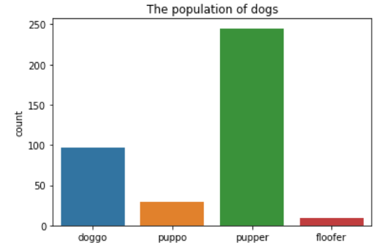

From the data we have, puppers appear most frequently on WeRateDogs -- At least people tend to remember the term of 'pupper' and are willing to use that in tweets.

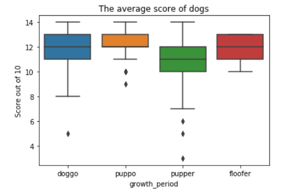

However, they have a lowest average score of rating among all the growth-periods.

## Put more images for a higher rating for your dog!

Since Twitter could upload at most 4 images in one tweet, it's interesting to explore whether uploading more images are beneficial to earning a higher rating for one's love dog. I explored the correlation between the number of images and the score of dogs, it turns out that: Yes, more images are correlated to higher scores, So if you want to earn higher ratings for your dog, have more photos!

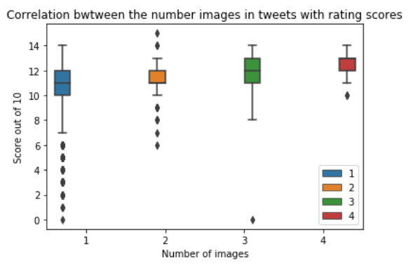

## People are not only interested in higher-rating dogs

However, people are not only interested in higher-rating dogs. Though they do tend to like and retweet more for high-scorers, they are also love to spread those who get severly low ratings. From the plot below, we could see that the scope of linear regression line suggests that there is a positive correlation between the number of retweets and likes a tweet get correlated to dog ratings. But when ratings are severly low, the number of retweets and likes a tweet get will also be slightly larger.

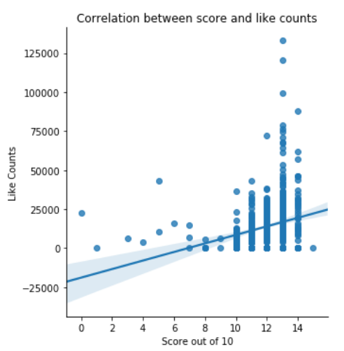

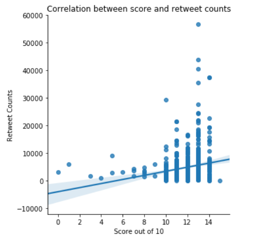

## Conclusion of Data Analysis

In conclusion, I have three key insights for @WeRateDogs:

1. Puppers appear most frequently on WeRateDogs -- At least people tend to remember the term of 'pupper' and are willing to use that in tweets. However, puppers have a lowest average score of rating among all the growth-periods.
2. There's a positive correlation between the number images in tweets with rating scores. So if one wants to have one's love dog rated higher, one could try upload more imgs for it.
3. People are not only interested in higher-rating dogs, though they tend to like and retweet more for high-scorers, they are also love to spread those who get severly low ratings.